# Exam 1

Carolina Herrera Figueroa

10/04/2021

# Instructions

1. Create a folder in your computer (a good place would be under Crim 250, Exams).
2. Download the dataset from the Canvas website (fatal-police-shootings-data.csv) onto that folder, and save your Exam 1.Rmd file in the same folder.
3. Download the README.md file. This is the codebook.
4. Load the data into an R data frame.

```r
dat<-read.csv("fatal-police-shootings-data.csv")
```

# Problem 1 (10 points)

1. Describe the dataset. This is the source: https://github.com/washingtonpost/data-police-shootings . Write two sentences (max.) about this.

**This dataset describes every fatal shooting in the United States since January 1, 2015 by a police officer on the line of duty. It tracks different variables about the circumstances of the shooting including if the victim was armed or not.**

2. How many observations are there in the data frame?

```r
dim(dat)
```

```
## [1] 6594   17
```

**The data consists of 6594 rows and 17 columns..**

3. Look at the names of the variables in the data frame. Describe what “body_camera”, “flee”, and “armed” represent, according to the codebook. Again, only write one sentence (max) per variable.

```r
names(dat)
```

```
##  [1] "id"                      "name"
##  [3] "date"                    "manner_of_death"
##  [5] "armed"                   "age"
##  [7] "gender"                  "race"
##  [9] "city"                    "state"
## [11] "signs_of_mental_illness" "threat_level"
## [13] "flee"                    "body_camera"
## [15] "longitude"               "latitude"
## [17] "is_geocoding_exact"
```

**The variable “body_camera” looks at whether news reports indicate that a officer was wearing a body camera and if it possibly recorded some part of the incident.“flee” looks at whether news reports indicate that the victim was moving away from the officers and there are three possible responses: “by foot”, “car” or “not fleeing”. “Armed” looks at whether the victim was armed with some sort of artifact that a police officer believed could inflict harm, the possible responses are that this is “undetermined”, “unknown” or the victim was “unarmed”.**

4. What are three weapons that you are surprised to find in the “armed” variable? Make a table of the values in “armed” to see the options.

```r
table(dat$armed)
```

```
##
##                                                   air conditioner
##                              207                                1
##                       air pistol                   Airsoft pistol
##                                1                                3
##                               ax                         barstool
##                               24                                1
##                     baseball bat          baseball bat and bottle
##                               20                                1
## baseball bat and fireplace poker           baseball bat and knife
##                                1                                1
##                            baton                           BB gun
##                                6                               15
##               BB gun and vehicle                     bean-bag gun
##                                1                                1
##                      beer bottle                       binoculars
##                                3                                1
##                     blunt object                           bottle
##                                5                                1
##                    bow and arrow                       box cutter
##                                1                               13
##                            brick              car, knife and mace
##                                2                                1
##                          carjack                            chain
##                                1                                3
##                        chain saw                         chainsaw
##                                2                                1
##                            chair              claimed to be armed
##                                4                                1
##               contractor's level                   cordless drill
##                                1                                1
##                         crossbow                          crowbar
##                                9                                5
##                        fireworks                         flagpole
##                                1                                1
##                       flashlight                      garden tool
##                                2                                2
##                      glass shard                          grenade
##                                4                                1
##                              gun                      gun and car
```

[output cut: 46 more lines]

```
##                                1                                5
##                            sword                            Taser
##                               23                               34
##                        tire iron                       toy weapon
##                                4                              226
##                          unarmed                     undetermined
##                              421                              188
##                   unknown weapon                          vehicle
##                               82                              213
##                  vehicle and gun              vehicle and machete
##                                8                                1
##                    walking stick                       wasp spray
##                                1                                1
##                           wrench
##                                1
```

**Three weapons that surprised me in the “armed” variable are pen, wasp spray, and chainsaw.**

# Problem 2 (10 points)

1. Describe the age distribution of the sample. Is this what you would expect to see?

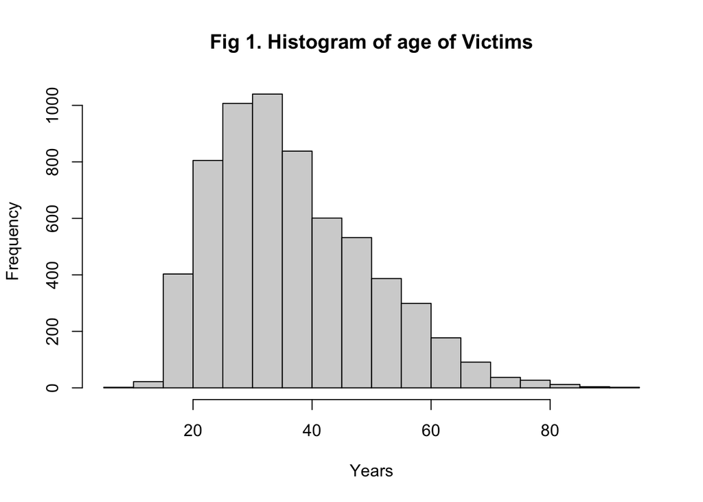

```r
hist(dat$age, main="Fig 1. Histogram of age of Victims", xlab="Years", ylab="Frequency")
```

2. To understand the center of the age distribution, would you use a mean or a median, and why? Find the one you picked.

```r
summary(dat$age)
```

```
##    Min. 1st Qu.  Median    Mean 3rd Qu.    Max.    NA's
##    6.00   27.00   35.00   37.12   45.00   91.00     308
```

**To understand the center of the age distribution I would use a median because it is resistant to values that are extremely large or small. Since the data is skewed to the right our mean would also be pulled to the right, giving us a number that does not represent the true center of the distribution. The median of the age distribution is 35 years old, meaning that the center of our data is located here.**

3. Describe the gender distribution of the sample. Do you find this surprising?

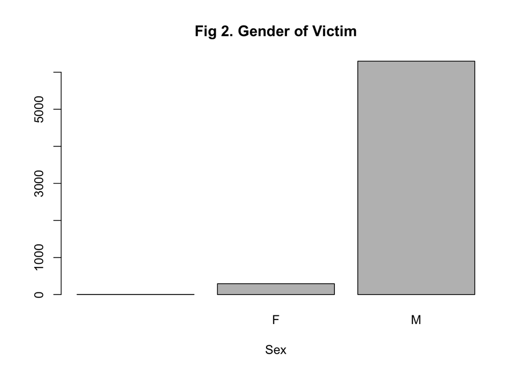

```r
counts <- table(dat$gender)
barplot(counts, main = "Fig 2. Gender of Victim", xlab="Sex")
```

**Figure 2 shows us that most of the victims were male, with a very small number identifying as female. I don’t find this surprising because usually when we hear about fatal police shootings the victims are always male. This could be either because they are more likley to put up a fight and resist to an arrest or because they are more likely to be stopped in the first place. The first very small bar in our chart signifies that the gender of the victim is unknown.**

# Problem 3 (10 points)

1. How many police officers had a body camera, according to news reports? What proportion is this of all the incidents in the data? Are you surprised that it is so high or low?

```r
table(dat$body_camera)
```

```
##
## False  True
##  5684   910
```

**According to news reports 910 police officers had a body camera. 910/6594 – Only in 13.8% of all incidents in the data police officers has a body camera. I found this to actually be very surprising considering the number of states that are requiring their officers to wear body cameras. I think it possible that a portion of these deadly shootings could have been prevented if more officers were required to wear these cameras, because they create a sense of responsibility. There is no way to lie about the circumstances of a deadly shooting if there is videographic evidence of what occurred.**

2. In how many of the incidents was the victim fleeing? What proportion is this of the total number of incidents in the data? Is this what you would expect?

```r
table(dat$flee)
```

```
##
##                     Car        Foot Not fleeing       Other
##         491        1058         845        3952         248
```

**The victim was fleeing in 1903 of the incidents, 1058 by car and 845 by foot. There are 491 missing values in this dataset, if we include those in the calculation, the victim was fleeing in 1903/6594 – 28.85% of the cases. If we do not include the missing values, the victim was fleeing in 31.18% of cases. This is not what I expected because it shows that the police officer did not have much reason to shoot the victim in a fatal way. If the individual isn’t fleeing then they are most likely not a source of imminent danger to the public, meaning there must be another way to get control over them. I would have expected the proportion of victims fleeing to be at least 50%.**

# Problem 4 (10 points) - Answer only one of these (a or b).

1. Describe the relationship between the variables “body camera” and “flee” using a stacked barplot. What can you conclude from this relationship?

*Hint 1: The categories along the x-axis are the options for “flee”, each bar contains information about whether the police officer had a body camera (vertically), and the height along the y-axis shows the frequency of that category).*

*Hint 2: Also, if you are unsure about the syntax for barplot, run ?barplot in R and see some examples at the bottom of the documentation. This is usually a good way to look up the syntax of R code. You can also Google it.*

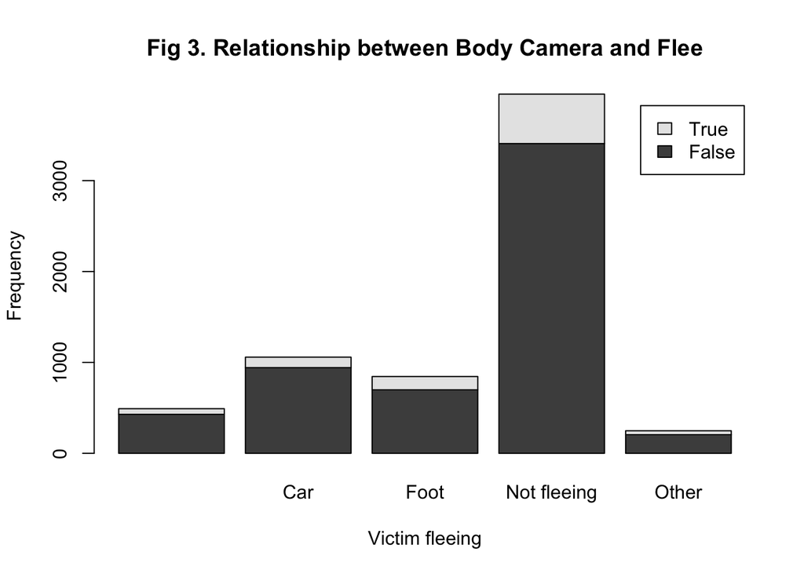

```r
tab.agesex <- table(dat$body_camera, dat$flee)
barplot(tab.agesex,
        main = "Fig 3. Relationship between Body Camera and Flee",
        xlab = "Victim fleeing", ylab = "Frequency",
        legend.text = rownames(tab.agesex),
        beside = FALSE) # Stacked bars (default)
```

**Figure 3 first shows us that most of the victims were not fleeing. Secondly, it shows us that more police officers were wearing cameras when the victim was not fleeing compared to when they were. I wouldn’t exactly say that there is an association between the two considering that police officers probably cannot take off their body cameras in the middle of their shift simply because it is convenient for the situation. I do think it’s off to see how in how many of these fatal shootings there is actual video evidence of what happened. The first bar in our plot is unlabeled in the dataset, so we are unsure of what that represents. There is also an “other” category where we see a small percentage of body cameras being used. I think this leaves a lot to think about because we don’t know if people in this category were fleeing or if there actions were open to ambiguity. This sort of makes me question the rest of the data and why some things aren’t specifically described or how were circumstances categorized. But overall, we can conclude that in our data more police officers were wearing body cameras that may have recoded part of the incident when the victim was not fleeing compared to when they were fleeing.**

2. Describe the relationship between age and race by using a boxplot. What can you conclude from this relationship?

*Hint 1: The categories along the x-axis are the race categories and the height along the y-axis is age.*

*Hint 2: Also, if you are unsure about the syntax for boxplot, run ?boxplot in R and see some examples at the bottom of the documentation. This is usually a good way to look up the syntax of R code. You can also Google it.*

# Extra credit (10 points)

1. What does this code tell us?

```r
mydates <- as.Date(dat$date)
head(mydates)
(mydates[length(mydates)] - mydates[1])
```

[output not shown]

**This code tells us the number of days that have passed since the first data point was collected. 2458 days have passed since January 1, 2015.**

2. On Friday, a new report was published that was described as follows by The Guardian: “More than half of US police killings are mislabelled or not reported, study finds.” Without reading this article now (due to limited time), why do you think police killings might be mislabelled or underreported? **I think some police killings might not be reported because it is unconvenient for the officer and the city. Perhaps it can affect their budget and how they are viewed by the public. The lack of body cameras also makes this more possible since we don’t have video evidence to prove exactly how the situation occurred.**
3. Regarding missing values in problem 4, do you see any? If so, do you think that’s all that’s missing from the data?